```python
import pprint
from IPython.display import HTML, display
pp = pprint.PrettyPrinter(indent=4, width=100)


HTML('''
<style>
.output_png {
    display: table-cell;
    text-align: center;
    vertical-align: middle;
}


</style>


<script>
code_show=true;
function code_toggle() {
 if (code_show){
 $('div.input').hide();
 } else {
 $('div.input').show();
 }
 code_show = !code_show
}
$( document ).ready(code_toggle);
</script>
<form action="javascript:code_toggle()"><input type="submit" value="Click here to toggle on/off the raw code."></form>
''')
```

# Neural Networks for Music Creation

Prepared by: Kisko V. Apeles MSDS 2021

The following references have been very helpful in the execution of this project:

- Music Generation using LSTMs: https://towardsdatascience.com/how-to-generate-music-using-a-lstm-neural-network-in-keras-68786834d4c5
- Source code: https://github.com/Skuldur/Classical-Piano-Composer
- BatchNorm: https://www.youtube.com/watch?v=DtEq44FTPM4
- class_weight: https://datascience.stackexchange.com/questions/13490/how-to-set-class-weights-for-imbalanced-classes-in-keras

# Executive Summary

Ever since, it has been my dream to become a songwriter / artist so I thought of creating music using neural networks. I used the humble LSTM architecture to predict note pitch, offsets, and duration of notes via separate models. The final models had acceptable final loss metrics and were able to generate music one could take inspiration from.

# Keywords

LSTM, MIDI, Music, Note Prediction

# Preliminaries

For this project, I utilized the efficient processing of Google Colaboratory.

## TPU Activation in Google Colaboratory

```python
%tensorflow_version 2.x
import tensorflow as tf
print("Tensorflow version " + tf.__version__)

try:
  tpu = tf.distribute.cluster_resolver.TPUClusterResolver()  # TPU detection
  print('Running on TPU ', tpu.cluster_spec().as_dict()['worker'])
except ValueError:
  raise BaseException('ERROR: Not connected to a TPU runtime; please see the previous cell in this notebook for instructions!')

tf.config.experimental_connect_to_cluster(tpu)
tf.tpu.experimental.initialize_tpu_system(tpu)
tpu_strategy = tf.distribute.experimental.TPUStrategy(tpu)
```

## Mount Google Drive in Google Colaboratory Notebook.

```python
from google.colab import drive
drive.mount('/content/drive', force_remount=True)
path = '/content/drive/MyDrive/NN/'
```

# Introduction

Since I was in high school, I wanted to make music and make people sing catchy lines. I wanted to make people feel.

Being a songwriter / artist is the dream. So I thought, why don't I use neural networks to create new music.

# Data and Methods

I have two originally composed demo songs that I can work with already and I wanted to try and create a song that is somewhere in between the two or a mix. The songs are available for listening here: https://soundcloud.com/kisko-apeles

[figure not shown]

To accomplish my objective, I chopped up the songs in MIDI format to 5 notes each as the input and the next note as the output as shown in the diagram below. Five notes were chosen as input for the dataset to still have enough notes for learning the intro of the songs.

[figure not shown]

Now that I have my dataset, I proceeded with the following methodology:

1. Exploratory Data Analysis
2. Training, Fine tuning, and Model Evaluation
3. MIDI Generation

## Exploratory Data Analysis

### Load Dataset for Exploratory Data Analysis

```python
import glob
import pickle
import numpy
from sklearn.utils.class_weight import compute_class_weight
from music21 import converter, instrument, note, chord
from keras.models import Sequential
from keras.layers import Dense
from keras.layers import Dropout
from keras.layers import LSTM
from keras.layers import Activation
from keras.layers import BatchNormalization as BatchNorm
from keras.utils import np_utils
from keras.callbacks import ModelCheckpoint

def train_network():
    """ Train a Neural Network to generate music """

    #Get all unique notes/chords of the all midi files
    all_notes = get_notes_vocab()

    #Determine number of unique notes/chords
    n_vocab = len(set(all_notes))

    for file in glob.glob(f"{path}midi_songs_test/*.mid"):
        midi = converter.parse(file) #Returns music21.stream.Score
        notes, offsets, durations = get_notes(midi)
        #GET INPUT/OUTPUT SEQUENCES PER SONG
        (network_input, network_output,
        network_input_offset,
        network_output_offset,
        network_input_duration,
        network_output_duration) = prepare_sequences(notes, n_vocab, offsets, durations, all_notes)

        #APPEND
        try:
          all_network_input = numpy.append(all_network_input, network_input, axis=0)
          all_network_output = numpy.append(all_network_output, network_output, axis=0)
          all_network_input_offset = numpy.append(all_network_input_offset, network_input_offset, axis=0)
          all_network_output_offset = numpy.append(all_network_output_offset, network_output_offset, axis=0)
          all_network_input_duration = numpy.append(all_network_input_duration, network_input_duration, axis=0)
          all_network_output_duration = numpy.append(all_network_output_duration, network_output_duration, axis=0)

        except Exception as e:
          all_network_input = network_input
          all_network_output = network_output
          all_network_input_offset = network_input_offset
          all_network_output_offset = network_output_offset
          all_network_input_duration = network_input_duration
          all_network_output_duration = network_output_duration

    with open(f'{path}data/all_network_input_duration', 'wb') as filepath:
        pickle.dump(all_network_input_duration, filepath)

    with open(f'{path}data/all_network_input_offset', 'wb') as filepath:
        pickle.dump(all_network_input_offset, filepath)

    with open(f'{path}data/all_network_input', 'wb') as filepath:
        pickle.dump(all_network_input, filepath)

    y_integers = numpy.argmax(all_network_output, axis=1)
    class_weights = compute_class_weight('balanced', numpy.unique(y_integers), y_integers)
    dict_class_weights = dict(enumerate(class_weights))

    model_duration = create_network_duration(all_network_input_duration, n_vocab)
    model_offset = create_network_offset(all_network_input_offset, n_vocab)
    model = create_network(all_network_input, n_vocab)

    print('\nTRAINING NOTES/CHORDS MODEL', '-'*20)
    train(model, all_network_input, all_network_output, dict_class_weights)
    print('\nTRAINING DURATION MODEL', '-'*20)
    train_duration(model_duration, all_network_input_duration, all_network_output_duration)
    print('\nTRAINING OFFSET MODEL', '-'*20)
    train_offset(model_offset, all_network_input_offset, all_network_output_offset)

def get_notes_vocab():
    """ Get all the notes and chords from the midi files in the ./midi_songs directory """
    notes = []

    for file in glob.glob(f"{path}midi_songs_test/*.mid"):
        midi = converter.parse(file) #Returns music21.stream.Score

        notes_to_parse = None

        try: # file has instrument parts
            s2 = instrument.partitionByInstrument(midi) #music21.stream.Score
            notes_to_parse = s2.parts[0].recurse()
        except: # file has notes in a flat structure #no rests
            notes_to_parse = midi.flat.notes

        for element in notes_to_parse:
            #If note, append to notes list
            if isinstance(element, note.Note):
                notes.append(str(element.pitch))
            #If chord, append to notes list
            elif isinstance(element, chord.Chord):
                notes.append('.'.join(str(n) for n in element.normalOrder))

    with open(f'{path}data/notes', 'wb') as filepath:
        pickle.dump(sorted(set(notes)), filepath)

    return sorted(set(notes))

def get_notes(midi):
    """ Get all the notes and chords of a midi file."""
    notes = []
    offsets = []
    durations = []

    notes_to_parse = None

    try: # file has instrument parts
        s2 = instrument.partitionByInstrument(midi) #music21.stream.Score
        notes_to_parse = s2.parts[0].recurse()
    except: # file has notes in a flat structure #no rests
        notes_to_parse = midi.flat.notes

    previous_offset = 0

    for element in notes_to_parse:

        #If note, append to notes list
        if isinstance(element, note.Note):
            notes.append(str(element.pitch))

            #Get offsets
            current_offset = element.offset
            offset_diff = current_offset - previous_offset
            previous_offset = element.offset
            offsets.append(numpy.float(offset_diff))

            #Get durations
            durations.append(numpy.float(element.duration.quarterLength))

        #If chord, append to notes list
        elif isinstance(element, chord.Chord):
            notes.append('.'.join(str(n) for n in element.normalOrder))

            #Get offsets
            current_offset = element.offset
            offset_diff = current_offset - previous_offset
            previous_offset = element.offset
            offsets.append(numpy.float(offset_diff))
            #offsets.append(numpy.float(element.offset))

            #Get durations
            durations.append(numpy.float(element.duration.quarterLength))

    return notes, offsets, durations

def prepare_sequences(notes, n_vocab, offsets, durations, all_notes):
    """ Prepare the sequences used by the Neural Network """
```

```python
    sequence_length = 5

    #Get all pitch names
    pitchnames = sorted(set(item for item in all_notes))

    #Create a dictionary to map pitches to integers (0 to ...)
    note_to_int = dict((note, number) for number, note in enumerate(pitchnames))
    #print('len(note_to_int.keys())', len(note_to_int.keys()))

    network_input = []
    network_output = []

    #For offset
    network_input_offset = []
    network_output_offset = []

    #For duration
    network_input_duration = []
    network_output_duration = []

    # create input sequences and the corresponding outputs
    # Input: 100 notes/chords, Output: 1 note
    for i in range(0, len(notes) - sequence_length, 1):
        #Input sectioning and output assigment
        sequence_in = notes[i:i + sequence_length]
        sequence_out = notes[i + sequence_length]
        #Input and output notes/chords are converted to integer counterparts
        #network_input is a list of lists of integers (0 to ...)
        network_input.append([note_to_int[char] for char in sequence_in])
        network_output.append(note_to_int[sequence_out])

        #For offset
        sequence_in_offset = offsets[i:i + sequence_length]
        sequence_out_offset = offsets[i + sequence_length]
        network_input_offset.append(sequence_in_offset)
        network_output_offset.append(sequence_out_offset)

        #For duration
        sequence_in_duration = durations[i:i + sequence_length]
        sequence_out_duration = durations[i + sequence_length]
        network_input_duration.append(sequence_in_duration)
        network_output_duration.append(sequence_out_duration)


    #Number of inputs generated from the midi files in total (and consequently outputs)
    n_patterns = len(network_input)

    #Reshape the input into a format compatible with LSTM layers
    #n_patterns by sequence_length matrix (per input)
    network_input = numpy.reshape(network_input, (n_patterns, sequence_length, 1))

    #Normalize input (Resulting value of elements in the matrix is within 0 and 1)
    #n_vocab is an input for the number of notes/chords
    network_input = network_input / float(n_vocab)

    #"Converts a class vector (integers) to binary class matrix." - Keras Documentation
    network_output = np_utils.to_categorical(network_output, num_classes=n_vocab)

    #For offset
    network_input_offset = numpy.reshape(network_input_offset, (n_patterns, sequence_length, 1))
    network_output_offset = numpy.array(network_output_offset)

    #For duration
    network_input_duration = numpy.reshape(network_input_duration, (n_patterns, sequence_length, 1))
    network_output_duration = numpy.array(network_output_duration)

    return (network_input, network_output,
           network_input_offset, network_output_offset,
           network_input_duration, network_output_duration)

def create_network(network_input, n_vocab):
    """ create the structure of the neural network """
    model = Sequential()
    model.add(LSTM(
        512,
        input_shape=(network_input.shape[1], network_input.shape[2]),
        recurrent_dropout=0.3,
        return_sequences=True
    ))
    model.add(LSTM(512, return_sequences=True, recurrent_dropout=0.3,))
    model.add(LSTM(512))
    model.add(BatchNorm())
    model.add(Dropout(0.3))
    model.add(Dense(256))
    model.add(Activation('relu'))
    model.add(BatchNorm())
    model.add(Dropout(0.3))
    model.add(Dense(n_vocab))
    model.add(Activation('softmax'))
    model.compile(loss='categorical_crossentropy', optimizer='rmsprop')

    return model

def create_network_offset(network_input_offset, n_vocab):
    """ create the structure of the neural network FOR OFFSET"""
    model = Sequential()
    model.add(LSTM(512,
        input_shape=(network_input_offset.shape[1], network_input_offset.shape[2]),
        recurrent_dropout=0.3,
        return_sequences=True
    ))
    model.add(LSTM(512, return_sequences=True,
                    ))
    model.add(LSTM(512))
    model.add(Dense(256))
    model.add(Activation('relu'))
    model.add(Dense(n_vocab))
    model.add(Dense(1))
    model.compile(loss='mae', optimizer='rmsprop')

    return model

def create_network_duration(network_input_duration, n_vocab):
    """ create the structure of the neural network FOR DURATION"""
    model = Sequential()
    model.add(LSTM(
        512,
        input_shape=(network_input_duration.shape[1], network_input_duration.shape[2]),
        return_sequences=True
    ))
    model.add(LSTM(512, return_sequences=True,
                   ))
    model.add(LSTM(512))
    model.add(BatchNorm())
    model.add(Dense(256))
    model.add(Activation('relu'))
    model.add(BatchNorm())
    model.add(Dense(n_vocab))
    model.add(Dense(1))
    model.compile(loss='mae', optimizer='rmsprop')

    return model

def train(model, network_input, network_output, dict_class_weights):
    """ train the neural network """
    filepath = f"{path}/checkpoint_weights/" + "weights-improvement-{epoch:02d}-{loss:.4f}-bigger.hdf5"
    checkpoint = ModelCheckpoint(
        filepath,
        monitor='loss',
        verbose=0,
        save_best_only=True,
        mode='min'
    )
    callbacks_list = [checkpoint]

    from keras.callbacks import EarlyStopping
    early_stopping_monitor = EarlyStopping(
    monitor='loss',
    min_delta=0,
    patience=50,
    verbose=0,
    mode='auto',
    baseline=None,
    restore_best_weights=True
)

    model.fit(network_input, network_output, epochs=100, batch_size=1024,
              callbacks=[early_stopping_monitor],
              class_weight=dict_class_weights,
              )

    import time
    insert = (str(time.time()) + ' ' + time.ctime() + ' + 8hrs').replace(' ', "_")
    insert
    model.save(f'{path}/models/model_{insert}.h5')

def train_offset(model, network_input_offset, network_output_offset):
    """ train the neural network """
    filepath = f"{path}/checkpoint_weights/offset/" + "weights-improvement-{epoch:02d}-{loss:.4f}-bigger.hdf5"
    checkpoint = ModelCheckpoint(
        filepath,
        monitor='loss',
        verbose=0,
        save_best_only=True,
        mode='min'
    )
    callbacks_list = [checkpoint]
```

```python
    from keras.callbacks import EarlyStopping
    early_stopping_monitor = EarlyStopping(
    monitor='loss',
    min_delta=0,
    patience=50,
    verbose=0,
    mode='auto',
    baseline=None,
    restore_best_weights=True
)

    model.fit(network_input_offset, network_output_offset, epochs=100, batch_size=1024,
              callbacks=[early_stopping_monitor]
              )

    import time
    insert = (str(time.time()) + ' ' + time.ctime() + ' + 8hrs').replace(' ', "_")
    insert
    model.save(f'{path}/models/model_offset_{insert}.h5')

def train_duration(model, network_input_duration, network_output_duration):
    """ train the neural network """
    filepath = f"{path}/checkpoint_weights/duration/" + "weights-improvement-{epoch:02d}-{loss:.4f}-bigger.hdf5"
    checkpoint = ModelCheckpoint(
        filepath,
        monitor='loss',
        verbose=0,
        save_best_only=True,
        mode='min'
    )
    callbacks_list = [checkpoint]

    from keras.callbacks import EarlyStopping
    early_stopping_monitor = EarlyStopping(
    monitor='loss',
    min_delta=0,
    patience=50,
    verbose=0,
    mode='auto',
    baseline=None,
    restore_best_weights=True
)

    model.fit(network_input_duration, network_output_duration, epochs=100, batch_size=1024,
              callbacks=[early_stopping_monitor]
              )

    import time
    insert = (str(time.time()) + ' ' + time.ctime() + ' + 8hrs').replace(' ', "_")
    insert
    model.save(f'{path}/models/model_duration_{insert}.h5')
```

```python
#Get all unique notes/chords of the all midi files
print('Generating notes/chords vocab.', '-'*20)
all_notes = get_notes_vocab()

#Determine number of unique notes/chords
n_vocab = len(set(all_notes))

#PER SONG
print('\nGenerating inputs/outputs for models.', '-'*20)
for file in glob.glob(f"{path}midi_songs_test/*.mid"):
    midi = converter.parse(file) #Returns music21.stream.Score
    notes, offsets, durations = get_notes(midi)

    #GET INPUT/OUTPUT SEQUENCES PER SONG
    (network_input, network_output,
    network_input_offset,
    network_output_offset,
    network_input_duration,
    network_output_duration) = prepare_sequences(notes, n_vocab, offsets, durations, all_notes)

    #APPEND
    try:
      all_network_input = numpy.append(all_network_input, network_input, axis=0)
      all_network_output = numpy.append(all_network_output, network_output, axis=0)
      all_network_input_offset = numpy.append(all_network_input_offset, network_input_offset, axis=0)
      all_network_output_offset = numpy.append(all_network_output_offset, network_output_offset, axis=0)
      all_network_input_duration = numpy.append(all_network_input_duration, network_input_duration, axis=0)
      all_network_output_duration = numpy.append(all_network_output_duration, network_output_duration, axis=0)
    except Exception as e:
      all_network_input = network_input
      all_network_output = network_output
      all_network_input_offset = network_input_offset
      all_network_output_offset = network_output_offset
      all_network_input_duration = network_input_duration
      all_network_output_duration = network_output_duration

with open(f'{path}data/all_network_input_duration', 'wb') as filepath:
    pickle.dump(all_network_input_duration, filepath)

with open(f'{path}data/all_network_input_offset', 'wb') as filepath:
    pickle.dump(all_network_input_offset, filepath)

with open(f'{path}data/all_network_input', 'wb') as filepath:
    pickle.dump(all_network_input, filepath)
```

I looked at the output note distribution of my dataset and I noticed that there are some notes that I prefer more than others.

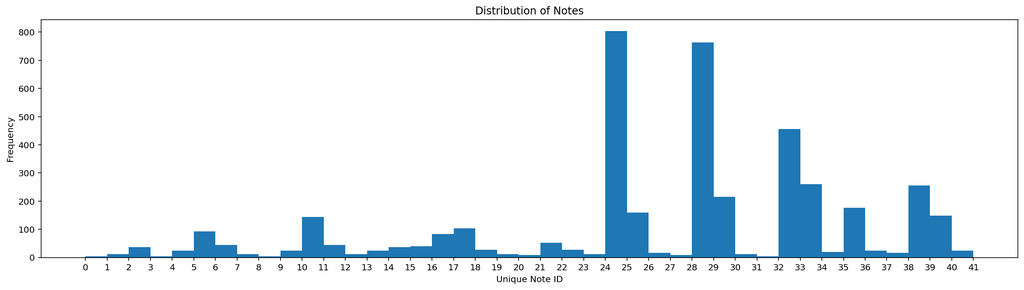

```python
import matplotlib.pyplot as plt
plt.figure(figsize=(20,5))
plt.hist(sorted([numpy.argmax(i) for i in all_network_output]), bins=range(0,n_vocab+1))
plt.xticks(ticks=range(0,n_vocab+1), labels=range(0,n_vocab+1))
plt.title('Distribution of Notes')
plt.ylabel('Frequency')
plt.xlabel('Unique Note ID')
plt.show()
```

### Generate Class Weights to Balance Note Prediction

Given that, I realized I had to alleviate the impact of this bias and after looking at the documentation of model.fit() in Keras, I saw that there is a class_weight argument which can take class weights per class that will modify the loss function and force the model to exert effort in learning to predict notes that are less represented than others.

```python
import numpy as np
from sklearn.utils.class_weight import compute_class_weight

y_integers = np.argmax(all_network_output, axis=1)
class_weights = compute_class_weight('balanced', np.unique(y_integers), y_integers)
dict_class_weights = dict(enumerate(class_weights))
```

## Training and Fine tuning

I used one of the model architectures for music creation shared in our LSTM notebook that was used in predicting the next songs. The LSTM used was a regular Stacked LSTM + Dense architecture but I saw an addition that is somewhat new to me, which is batch normalization. Upon searching what batch normalization mostly impacts, I learned that it helps a lot in speeding up training time by normalizing the inputs before activation functions.

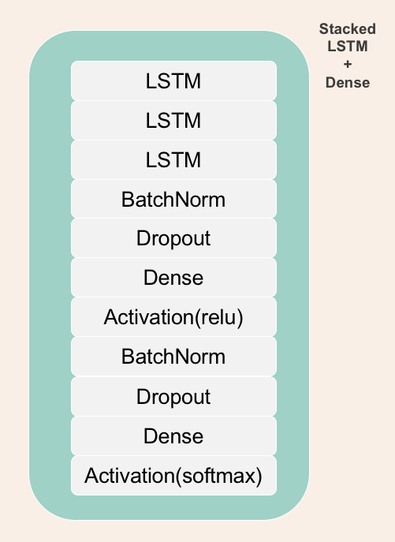

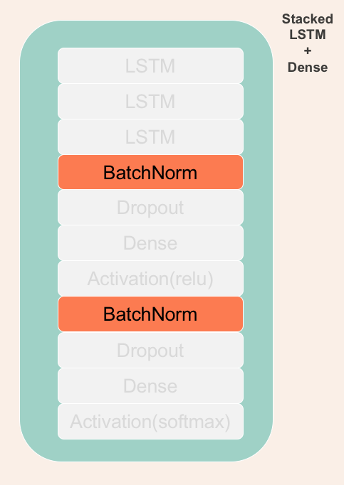

To hopefully add more flavor to the music generation, I added two LSTMs parallel to it to also predict offset, the distance between notes, and duration, how long the notes are played or sustained. I built them separately because I wanted to mix and match the offset timing of genres with notes profile of other genres later on if ever this architecture will be effective.

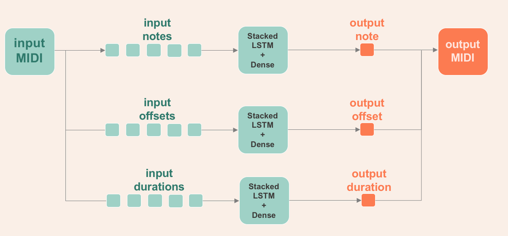

In the fitting of the model, I also added class weights since my dataset was unbalanced where some notes or chords were more represented than others.

In tuning the model, I played around with the following parameters:

1. No of hidden nodes.
2. No of dense layers.
3. No of batch norm layers
4. No of dropout layers

I stopped tuning when the output MIDI was almost acceptable to my ears.

```python
train_network()
```

# Results and Discussion

After tuning the three models and further adding training epochs, I have arrived at these final architectures. With the following evaluation metric results:

## Notes Prediction Model

```python
from keras.models import load_model

model = load_model(f'{path}/models/model_1609029058.9171872_Sun_Dec_27_00:30:58_2020_+_8hrs.h5')
model.summary()
model.evaluate(all_network_input, all_network_output)
```

```
Model: "sequential_17"
_________________________________________________________________
Layer (type)                 Output Shape              Param #
=================================================================
lstm_51 (LSTM)               (None, 5, 512)            1052672
_________________________________________________________________
lstm_52 (LSTM)               (None, 5, 512)            2099200
_________________________________________________________________
lstm_53 (LSTM)               (None, 512)               2099200
_________________________________________________________________
batch_normalization_34 (Batc (None, 512)               2048
_________________________________________________________________
dropout_34 (Dropout)         (None, 512)               0
_________________________________________________________________
dense_46 (Dense)             (None, 256)               131328
_________________________________________________________________
activation_22 (Activation)   (None, 256)               0
_________________________________________________________________
batch_normalization_35 (Batc (None, 256)               1024
_________________________________________________________________
dropout_35 (Dropout)         (None, 256)               0
_________________________________________________________________
dense_47 (Dense)             (None, 41)                10537
_________________________________________________________________
activation_23 (Activation)   (None, 41)                0
=================================================================
Total params: 5,396,009
Trainable params: 5,394,473
Non-trainable params: 1,536
_________________________________________________________________
```

```
0.2555534243583679
```

## Duration Prediction Model

```python
from keras.models import load_model

model_duration = load_model(f'{path}/models/model_duration_1609344061.166753_Wed_Dec_30_16:01:01_2020_+_8hrs.h5')
model_duration.summary()
model_duration.evaluate(all_network_input_duration, all_network_output_duration)
#MAE
```

```
Model: "sequential_33"
_________________________________________________________________
Layer (type)                 Output Shape              Param #
=================================================================
lstm_93 (LSTM)               (None, 5, 512)            1052672
_________________________________________________________________
lstm_94 (LSTM)               (None, 5, 512)            2099200
_________________________________________________________________
lstm_95 (LSTM)               (None, 512)               2099200
_________________________________________________________________
batch_normalization_48 (Batc (None, 512)               2048
_________________________________________________________________
dense_84 (Dense)             (None, 256)               131328
_________________________________________________________________
activation_42 (Activation)   (None, 256)               0
_________________________________________________________________
batch_normalization_49 (Batc (None, 256)               1024
_________________________________________________________________
dense_85 (Dense)             (None, 41)                10537
_________________________________________________________________
dense_86 (Dense)             (None, 1)                 42
=================================================================
Total params: 5,396,051
Trainable params: 5,394,515
Non-trainable params: 1,536
_________________________________________________________________
```

```
0.8034248948097229
```

## Offset Prediction Model

```python
from keras.models import load_model

model_offset = load_model(f'{path}/models/model_offset_1609419170.9057908_Thu_Dec_31_12:52:50_2020_+_8hrs.h5')
model_offset.summary()
model_offset.evaluate(all_network_input_offset, all_network_output_offset)
```

```
Model: "sequential_4"
_________________________________________________________________
Layer (type)                 Output Shape              Param #
=================================================================
lstm_10 (LSTM)               (None, 5, 512)            1052672
_________________________________________________________________
lstm_11 (LSTM)               (None, 5, 512)            2099200
_________________________________________________________________
lstm_12 (LSTM)               (None, 512)               2099200
_________________________________________________________________
dense_9 (Dense)              (None, 256)               131328
_________________________________________________________________
activation_4 (Activation)    (None, 256)               0
_________________________________________________________________
dense_10 (Dense)             (None, 41)                10537
_________________________________________________________________
dense_11 (Dense)             (None, 1)                 42
=================================================================
Total params: 5,392,979
Trainable params: 5,392,979
Non-trainable params: 0
_________________________________________________________________
```

```
0.13923048973083496
```

## MIDI Generation

I used the models to generate a MIDI file (see included “output.midi”) and I was a bit off timing. It seemed that the LSTM architecture only learned how to predict the next note due to the model architecture but was not able to learn the structure of the song (i.e., intro-verse-chorus-verse-etc).

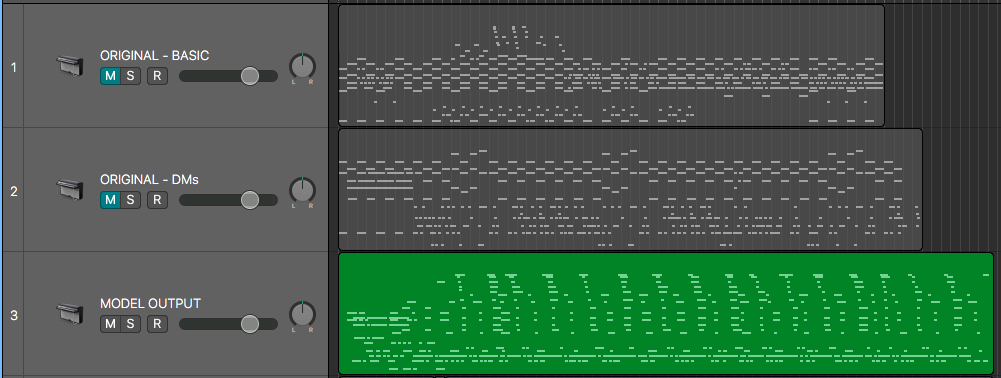

```python
import pickle
import numpy
from music21 import instrument, note, stream, chord
from keras.models import Sequential
from keras.layers import Dense
from keras.layers import Dropout
from keras.layers import LSTM
from keras.layers import BatchNormalization as BatchNorm
from keras.layers import Activation
from keras.models import load_model

def generate(model, model_offset, model_duration, added_name='', start=0):
    """ Generate a piano midi file """
    print('Starting generation.')

    #load the notes used to train the model
    with open(f'{path}data/notes', 'rb') as filepath:
        notes = pickle.load(filepath)

    with open(f'{path}data/all_network_input_duration', 'rb') as filepath:
        all_network_input_duration = pickle.load(filepath)

    with open(f'{path}data/all_network_input_offset', 'rb') as filepath:
        all_network_input_offset = pickle.load(filepath)

    with open(f'{path}data/all_network_input', 'rb') as filepath:
        all_network_input = pickle.load(filepath)  #Normalized already

    # Get number of pitchnames
    n_vocab = len(set(notes))

    (prediction_output,
     prediction_output_offset,
     prediction_output_duration) = generate_notes(model,
                                                  all_network_input,
                                                notes,
                                                n_vocab,
                                                model_offset,
                                                all_network_input_offset,
                                                model_duration,
                                                all_network_input_duration,
                                                start
                   )
    create_midi(prediction_output, prediction_output_offset,
                prediction_output_duration,
                added_name=added_name)
    print('Done generating.')

def prepare_sequences(notes, pitchnames, n_vocab, offsets, durations):
    """ Prepare the sequences used by the Neural Network """
    print('Preparing sequences.')
    note_to_int = dict((note, number) for number, note in enumerate(pitchnames))

    sequence_length = 5
    network_input = []
    network_input_offset = []
    network_input_duration = []

    for i in range(0, len(notes) - sequence_length, 1):
        sequence_in = notes[i:i + sequence_length]
        network_input.append([note_to_int[char] for char in sequence_in])
        sequence_in_offset = offsets[i:i + sequence_length]
        network_input_offset.append(sequence_in_offset)
        sequence_in_duration = durations[i:i + sequence_length]
        network_input_duration.append(sequence_in_duration)

    n_patterns = len(network_input)

    normalized_input = numpy.reshape(network_input, (n_patterns, sequence_length, 1))
    normalized_input = normalized_input / float(n_vocab)
    network_input_offset = numpy.reshape(network_input_offset, (n_patterns, sequence_length, 1))
    network_input_duration = numpy.reshape(network_input_duration, (n_patterns, sequence_length, 1))

    return (network_input, normalized_input,
            network_input_offset, network_input_duration)

def create_network(network_input, n_vocab):
    """ create the structure of the neural network """
    print('Creating network.')
    model = Sequential()
    model.add(LSTM(
        512,
        input_shape=(network_input.shape[1], network_input.shape[2]),
        recurrent_dropout=0.3,
        return_sequences=True
    ))
    model.add(LSTM(512, return_sequences=True, recurrent_dropout=0.3,))
    model.add(LSTM(512))
    model.add(BatchNorm())
    model.add(Dropout(0.3))
    model.add(Dense(256))
    model.add(Activation('relu'))
    model.add(BatchNorm())
    model.add(Dropout(0.3))
    model.add(Dense(n_vocab))
    model.add(Activation('softmax'))
    model.compile(loss='categorical_crossentropy', optimizer='rmsprop')

    # Load the weights to each node
    model.load_weights(f'{path}weights.hdf5')

    return model

def create_network_offset(network_input_offset, n_vocab):
    """ create the structure of the neural network FOR OFFSET"""
    model = Sequential()
    model.add(LSTM(
        512,
        input_shape=(network_input_offset.shape[1], network_input_offset.shape[2]),
        recurrent_dropout=0.3,
        return_sequences=True
    ))
    model.add(LSTM(512, return_sequences=True, recurrent_dropout=0.3,))
    model.add(LSTM(512))
    model.add(BatchNorm())
    model.add(Dropout(0.3))
    model.add(Dense(256))
    model.add(Activation('relu'))
    model.add(BatchNorm())
    model.add(Dropout(0.3))
    model.add(Dense(n_vocab))
    model.add(Dense(1))
    model.compile(loss='mse', optimizer='rmsprop')

    # Load the weights to each node
    model.load_weights(f'{path}offset_weights.hdf5')

    return model

def create_network_duration(network_input_duration, n_vocab):
    """ create the structure of the neural network FOR OFFSET"""
    model = Sequential()
    model.add(LSTM(
        512,
        input_shape=(network_input_duration.shape[1], network_input_duration.shape[2]),
        recurrent_dropout=0.3,
        return_sequences=True
    ))
    model.add(LSTM(512, return_sequences=True, recurrent_dropout=0.3,))
    model.add(LSTM(512))
    model.add(BatchNorm())
    model.add(Dropout(0.3))
    model.add(Dense(256))
    model.add(Activation('relu'))
    model.add(BatchNorm())
    model.add(Dropout(0.3))
    model.add(Dense(n_vocab))
    model.add(Dense(1))
    model.compile(loss='mse', optimizer='rmsprop')

    # Load the weights to each node
    model.load_weights(f'{path}duration_weights.hdf5')

    return model

def generate_notes(model,
                   network_input,
                   pitchnames,
                   n_vocab,
                   model_offset,
                   network_input_offset,
                   model_duration,
                   network_input_duration,
                   start):
    """ Generate notes from the neural network based on a sequence of notes """
    print('Generating notes.')

    # pick a random sequence from the input as a starting point for the prediction
    start = numpy.random.randint(0, len(network_input)-1)

    #Dictionary for converting integer predictions to notes/chords
    int_to_note = dict((number, note) for number, note in enumerate(pitchnames))

    #Starting input for prediction
    pattern = network_input[start] #PSOE, check shape
    prediction_output = []

    #For offset
    #Starting input for prediction
    pattern_offset = network_input_offset[start] #PSOE, check shape
    prediction_output_offset = []

    #For duration
    #Starting input for prediction
    pattern_duration = network_input_duration[start] #PSOE, check shape
    prediction_output_duration = []

    #Generate 500 notes
    for note_index in range(500):

        #Reshape for NN input
        prediction_input = numpy.reshape(pattern, (1, len(pattern), 1))
        prediction = model.predict(prediction_input, verbose=0)
        index = numpy.argmax(prediction)
        result = int_to_note[index]
        prediction_output.append(result)
        index = numpy.reshape(index, (len([index]), 1)) / float(n_vocab)
        pattern = numpy.append(pattern, index, axis=0)
        pattern = pattern[1:len(pattern)]

        #For offset
        #Reshape for NN input
        prediction_input_offset = numpy.reshape(pattern_offset, (1, len(pattern_offset), 1))
        #Predict an output from an input using a model
        prediction_offset = model_offset.predict(prediction_input_offset, verbose=0)
        #Append resulting offset in output
        prediction_output_offset.append(prediction_offset)
        #Append new offset
        #pattern_offset.append(prediction_offset)
        pattern_offset = numpy.append(pattern_offset, prediction_offset) #PSOE
        #Update input pattern for prediction
        pattern_offset = pattern_offset[1:len(pattern)]

        #For duration
        #Reshape for NN input
        prediction_input_duration = numpy.reshape(pattern_duration, (1, len(pattern_duration), 1))
        #Predict an output from an input using a model
        prediction_duration = model_duration.predict(prediction_input_duration, verbose=0)
        #Append resulting duration in output
        prediction_output_duration.append(prediction_duration)
        #Append new duration
        #pattern_duration.append(prediction_duration)
        pattern_duration = numpy.append(pattern_duration, prediction_duration) #PSOE
        #Update input pattern for prediction
        pattern_duration = pattern_duration[1:len(pattern)]


    #Return list of notes/chords
    return prediction_output, prediction_output_offset, prediction_output_duration

def create_midi(prediction_output, prediction_output_offset,
                prediction_output_duration, added_name=''):
    """ convert the output from the prediction to notes and create a midi file
        from the notes """

    def closest_duration_residual(residual):
      "Map duration residual to possible parsable value."
      possible_duration_residuals = [0, 0.25, 1/3, 0.5, 2/3, 0.75, 1]
      K = residual
      lst = possible_duration_residuals
      return lst[min(range(len(lst)), key = lambda i: abs(lst[i]-K))]

    print('Creating midi.')
    offset = 0
    output_notes = []

    #Create note and chord objects based on the values generated by the model
    #For each note/chord in the prediction output for creating midi file
    for pattern, offset_update, duration in zip(prediction_output,
                                      prediction_output_offset,
                                      prediction_output_duration):

        offset += offset_update.flatten()[0]
        duration = duration.flatten()[0]

        #If pattern is a chord
        if ('.' in pattern) or pattern.isdigit():
            #Split chords in string into notes
            notes_in_chord = pattern.split('.')

            #Container for notes
            notes = []

            #For each note in chord
            for current_note in notes_in_chord:
                #Convert to parsable note
                new_note = note.Note(int(current_note))
                #Set note for piano instrument
                new_note.storedInstrument = instrument.Piano()
                #Append parsable note in notes list to form chord
                notes.append(new_note)
            #Convert to parsable chord
            new_chord = chord.Chord(notes)
            #Apply offset
            new_chord.offset = offset
            #Apply duration
            whole, residual = duration//1, duration%1
            residual = closest_duration_residual(residual)
            new_chord.duration.quarterLength = whole + residual
            #Append parsable chord in output notes
            output_notes.append(new_chord)
        #If pattern is a note
        else:
            #Convert to parsable note
            new_note = note.Note(pattern)
            #Apply offset
            new_note.offset = offset
            #Apply duration
            whole, residual = duration//1, duration%1
            residual = closest_duration_residual(residual)
            new_note.duration.quarterLength = whole + residual
            #Set note for piano instrument
            new_note.storedInstrument = instrument.Piano()
            #Append parsable note in output notes
            output_notes.append(new_note)

    midi_stream = stream.Stream(output_notes)
    import time
    midi_stream.write('midi', fp=f'{path}test_output_{time.time()}_{added_name}.mid')
```

```python
from keras.models import load_model
from tqdm.autonotebook import tqdm

model_names = ['model_1609494353.8545516_Fri_Jan__1_09:45:53_2021_+_8hrs.h5']
starting_points=[0]
model_offset = load_model(f'{path}/models/model_offset_1609419170.9057908_Thu_Dec_31_12:52:50_2020_+_8hrs.h5')
model_duration = load_model(f'{path}/models/model_duration_1609037609.5154614_Sun_Dec_27_02:53:29_2020_+_8hrs.h5')

for model_name in tqdm(model_names):
  for starting_point in tqdm(starting_points):
    model = load_model(f'{path}/models/{model_name}')
    generate(model, model_offset, model_duration, model_name, starting_point)
```

# Conclusion and Recommendations

In conclusion, the LSTM architecture for song prediction was able to generate fairly accurate notes, offsets, and durations. However, it was not yet able to learn the structure of the song (i.e., intro-verse-chorus-verse-etc).

Further modifications can still be done to improve the results of the model. These improvements are the following:

1. Increase the notes per input-output pair.
2. Use other architectures like transformers or auto-encoders.
3. Add more song inputs.

For now, its output can instead be used to generate music one could take inspiration from.